# Model Predicting Exercise Manner

Anusha Bhat

Saturday, November 21, 2015

This project uses data from accelerometers on the belt, forearm, arm, and dumbell of 6 participants that performed barbell lifts correctly and incorrectly in 5 different ways. The goal of the project is to predict the manner in which they did the exercise.

“classe” variable indicating one of 5 class of activities is used as output variable to be predicted. Variables to predict with are selected from the training set to build the model.

## Analysis

### Model Selection

```r
fileUrl <- getURL("https://d396qusza40orc.cloudfront.net/predmachlearn/pml-training.csv", ssl.verifypeer=0L, followlocation=1L)

writeLines(fileUrl,'training.csv')

traindf <- read.csv("training.csv")

traindf <- traindf[ , apply(traindf, 2, function(x) {!sum(is.na(x))})]

traindf <- traindf[ , -grep("kurtosis|skewness|max|min|amplitude", names(traindf), ignore.case = TRUE)]

traindf <- traindf[, - c(traindf$user_name, traindf$cvtd_timestamp, traindf$new_window)]
```

The training set is split into a 70% by 30% train and test data.

```r
inTrain <- createDataPartition(traindf$classe, p = .7, list = FALSE)

trainingSet <- traindf[inTrain,]

testingSet <- traindf[-inTrain,]
```

The training data is fit with Random Forest to predict the output class. Random Forest is chosen after fitting the training dataset other models (i.e. gbm and decision trees) based on accuracy of model to predict class in testing dataset. Train Control is used in the model to improve computational performance by resampling the training dataset 4 times for cross validation. The accuracy of the model used is quite high shown in the results.

```r
trainCntrl <- trainControl(method="cv", number = 4, allowParallel=TRUE)

modFit <- train(classe~., method="rf", data=trainingSet, trControl=trainCntrl)
modFit
```

```
## Random Forest
##
## 13737 samples
##    39 predictor
##     5 classes: 'A', 'B', 'C', 'D', 'E'
##
## No pre-processing
## Resampling: Cross-Validated (4 fold)
## Summary of sample sizes: 10303, 10304, 10302, 10302
## Resampling results across tuning parameters:
##
##   mtry  Accuracy   Kappa      Accuracy SD  Kappa SD
##    2    0.9785253  0.9728255  0.001991901  0.002525355
##   20    0.9804179  0.9752222  0.002182962  0.002765430
##   39    0.9670236  0.9582761  0.004580145  0.005806335
##
## Accuracy was used to select the optimal model using  the largest value.
## The final value used for the model was mtry = 20.
```

### Testing Predictions

The testing dataset created from the raw training data is used to test the rf model. The accuracy of predictions is 99% and the model is significant. The plot shows red points for rows with incorrect predictions when total arm acceleration and total dumbbell acceleration are plotted against each other.

```r
pred <- predict(modFit, testingSet)
conf <- confusionMatrix(pred, testingSet$classe)

conf
```

```
## Confusion Matrix and Statistics
##
##           Reference
## Prediction    A    B    C    D    E
##          A 1673    8    0    1    0
##          B    1 1129    4    0    0
##          C    0    2 1020   12    1
##          D    0    0    1  947    1
##          E    0    0    1    4 1080
##
## Overall Statistics
##
##                Accuracy : 0.9939
##                  95% CI : (0.9915, 0.9957)
##     No Information Rate : 0.2845
##     P-Value [Acc > NIR] : < 2.2e-16
##
##                   Kappa : 0.9923
##  Mcnemar's Test P-Value : NA
##
## Statistics by Class:
##
##                      Class: A Class: B Class: C Class: D Class: E
## Sensitivity            0.9994   0.9912   0.9942   0.9824   0.9982
## Specificity            0.9979   0.9989   0.9969   0.9996   0.9990
## Pos Pred Value         0.9946   0.9956   0.9855   0.9979   0.9954
## Neg Pred Value         0.9998   0.9979   0.9988   0.9966   0.9996
## Prevalence             0.2845   0.1935   0.1743   0.1638   0.1839
## Detection Rate         0.2843   0.1918   0.1733   0.1609   0.1835
## Detection Prevalence   0.2858   0.1927   0.1759   0.1613   0.1844
## Balanced Accuracy      0.9986   0.9951   0.9955   0.9910   0.9986
```

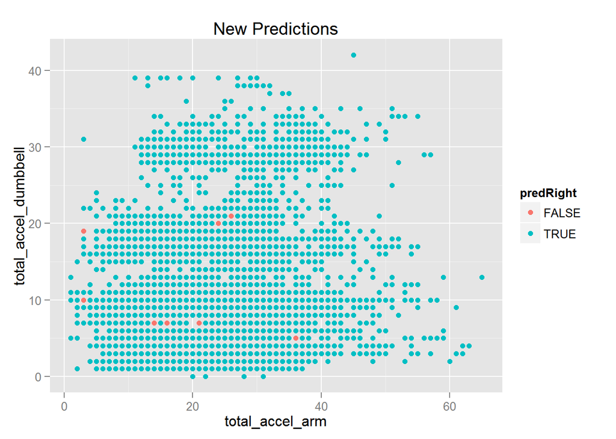

```r
testingSet$predRight <- pred == testingSet$classe
qplot(total_accel_arm, total_accel_dumbbell, color=predRight, data=testingSet, main="New Predictions")
```

### Out of Sample Error

```r
OOSAccuracy <- sum(pred == testingSet$classe)/length(pred)

OOSErr <- 1 - OOSAccuracy

OOSErr
```

```
## [1] 0.006117247
```

## Results

```r
fileUrl2 <- getURL("https://d396qusza40orc.cloudfront.net/predmachlearn/pml-testing.csv", ssl.verifypeer=0L, followlocation=1L)

writeLines(fileUrl2,'testing.csv')

testdf <- read.csv("testing.csv")

answers <- predict(modFit, testdf)

pml_write_files = function(x){
    n = length(x)
    for(i in 1:n){
        filename = paste0("problem_id_",i,".txt")
        write.table(x[i],file=filename,quote=FALSE,row.names=FALSE,col.names=FALSE)
    }
}

pml_write_files(answers)
```